# NBAStats_Vignette

Teresa DeAtley

December 10, 2017

## NBA Stats Package Discription

NBA stats is a package that pulls live NBA statistics from the website https://www.basketball-reference.com/ from 2008 through 2018.

In addition to pulling team statistics directly off of the web, a number of fucntions have been added to pull from the live NBA statistics.

The package:

1.First, scrapes from the webpages for different statistics

2.Second, combines all the scaped tables into a tibble

3.Third, cleans all the data

4.Fourth, loads the functions

A list of our functions include:

1. A function that sets abbreviations to team names
2. A function that calculates win probability
3. A betting function that allows the user to specify two teams and get the daily odds of winning
4. A function to that provides the last match up dates between teams
5. A function that provides a team’s season stats during regular season
6. A function that provides the specified team’s schedule
7. A function that sets team’s names to abbreviations
8. A function that provides play-off statistics
9. A function that gets the schedule for all teams in the league during regular season and playoffs
10. A function that populates a U.S. map of the games played on a specified date, visualized by home team name and arena
11. A function that provides team standings in the league
12. A function that provides team statistics during the playoffs

A glossary of the the statistics that are available here: [Glossary](https://docs.google.com/spreadsheets/d/1TlsKr_mAhdhPn4hHUFHKRyVnVLpAuTW7LVbc1eKcjKc/edit?usp=sharing)

For picture examples of what each section in the glossary maps to on the website see the following sections below:

“Heading” can be seen on the home page such as “Teams” or “Playoffs”. See example:

[figure not shown]

Subsections, can be selected from a particular heading, such as the franchise the “Boston Celtics”. See example:

[figure not shown]

Lastly, the list of statistic tables avilable which are pulled directly from the website. See example:

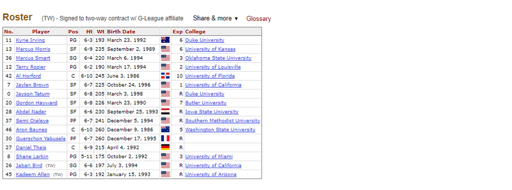